# Analysis Report

MG

Modified: 2023-03-07

# 1 Business Task Statement

The purpose of this study is to get some insights of space missions that took place from 1957-2022. The data for this study is located at [1] and contains 4,630 records regarding space missions around the world for the period 10/4/1957 - 07/29/2022.

More specifically, this report finds answers to the following questions

- Launches:
  - How many launches in total
  - How many successful/failed launches?
- Facilities:
  - How many launches per facility?
  - Which countries launched space missions?
- Rockets:
  - How many rockets?
  - How many is active vs. retiered?
  - Which rockets were used the most?
  - Which rockets served the longest?

# 2 Findings

Findings regard period 10/4/1957 - 7/29/2022, unless stated otherwise.

- There were 4630 launches in total.
- There were 47 facilities capable of rocket launch.
- Facilities were located in 20 countries (or areas).
- 87% of facilities performed no more than 200 launches in total.

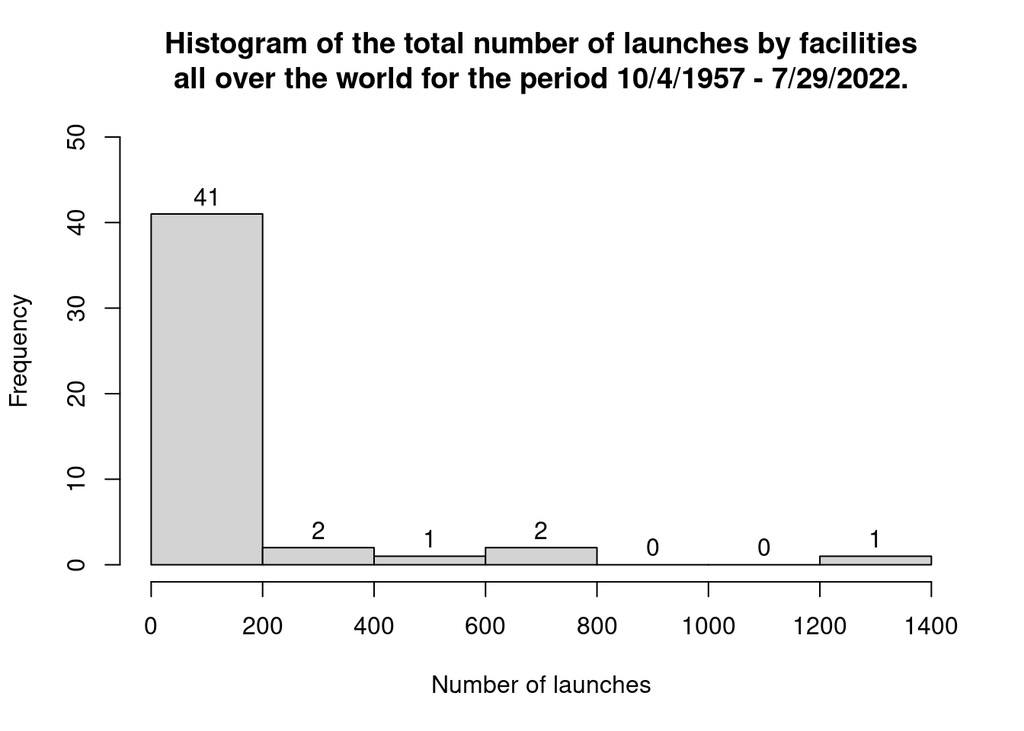

## 2.1 Facilities

- A country can have several launching facilities.

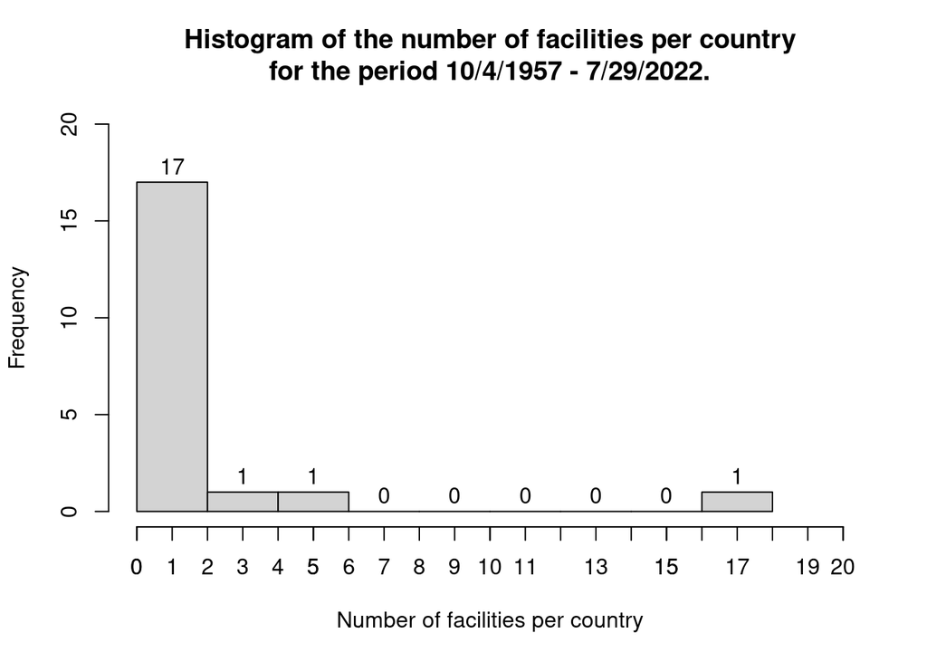

- Facilities were located in 20 countries.
- There were two locations with undefined country of ownership: Yellow Sea, and Barents Sea, where rockets were launched from submarines (Barents Sea) or barges (Yellow Sea).

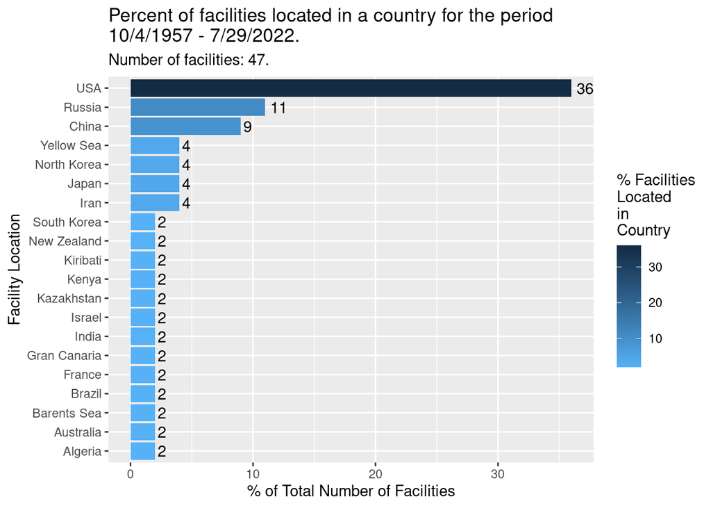

Table 2.1: Facilities per location/country for the period 10/4/1957 - 7/29/2022.

| Area | FacilityCount | Percent |
| --- | --- | --- |
| USA | 17 | 36 |
| Russia | 5 | 11 |
| China | 4 | 9 |
| Iran | 2 | 4 |
| Japan | 2 | 4 |
| North Korea | 2 | 4 |
| Yellow Sea | 2 | 4 |
| Algeria | 1 | 2 |
| Australia | 1 | 2 |
| Barents Sea | 1 | 2 |
| Brazil | 1 | 2 |
| France | 1 | 2 |
| Gran Canaria | 1 | 2 |
| India | 1 | 2 |
| Israel | 1 | 2 |
| Kazakhstan | 1 | 2 |
| Kenya | 1 | 2 |
| Kiribati | 1 | 2 |
| New Zealand | 1 | 2 |
| South Korea | 1 | 2 |

- Eight countries were used by more than one company. Top 5 most popular launching locations:
  - USA (used by 21 companies),
  - Kazakhstan (used by 11 companies),
  - Russia (used by 9 companies),
  - China (used by 8 companies),
  - Japan (used by 4 companies).

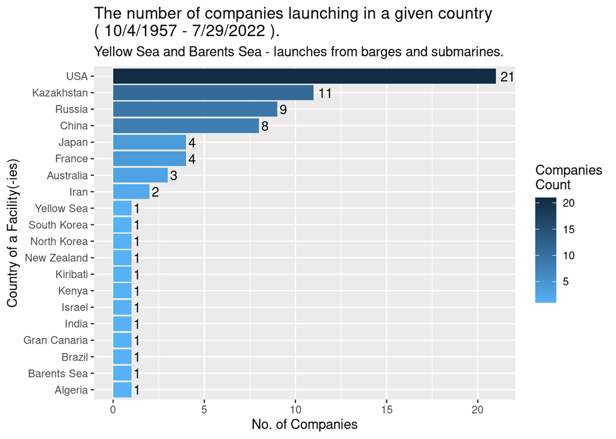

## 2.2 Companies

- There were 62 companies that launched space missions.
- 50 companies launched in a single country/location.
- There were twelve companies that launched space missions in two different countries.

## 2.3 Launches

- Top 5 countries/locations (USA, Russia, Kazahstan, China, France) account for over 92% of global launches. There were 4630 launches in total.

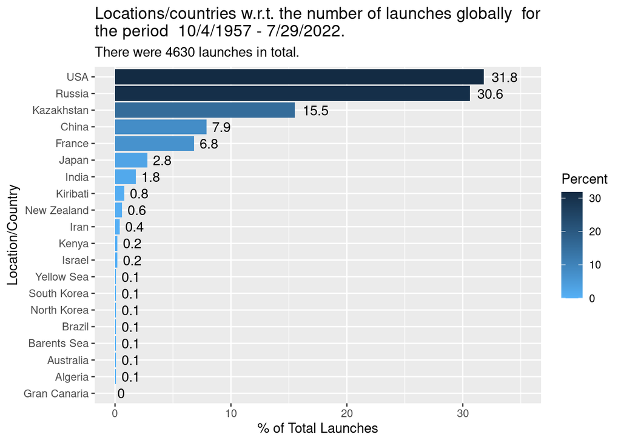

Table 2.2: Locations/countries launching space missions ordered by percentage of the global number of launches for the period 10/4/1957 - 7/29/2022.

| Area | Total | Percent |
| --- | --- | --- |
| USA | 1472 | 31.8 |
| Russia | 1416 | 30.6 |
| Kazakhstan | 719 | 15.5 |
| China | 365 | 7.9 |
| France | 314 | 6.8 |
| Japan | 130 | 2.8 |
| India | 82 | 1.8 |
| Kiribati | 36 | 0.8 |
| New Zealand | 28 | 0.6 |
| Iran | 17 | 0.4 |
| Israel | 11 | 0.2 |
| Kenya | 9 | 0.2 |
| Australia | 6 | 0.1 |
| North Korea | 5 | 0.1 |
| South Korea | 5 | 0.1 |
| Algeria | 4 | 0.1 |
| Barents Sea | 3 | 0.1 |
| Brazil | 3 | 0.1 |
| Yellow Sea | 3 | 0.1 |
| Gran Canaria | 2 | 0.0 |

- Top 10 launching facilities taking into account the number of launches.

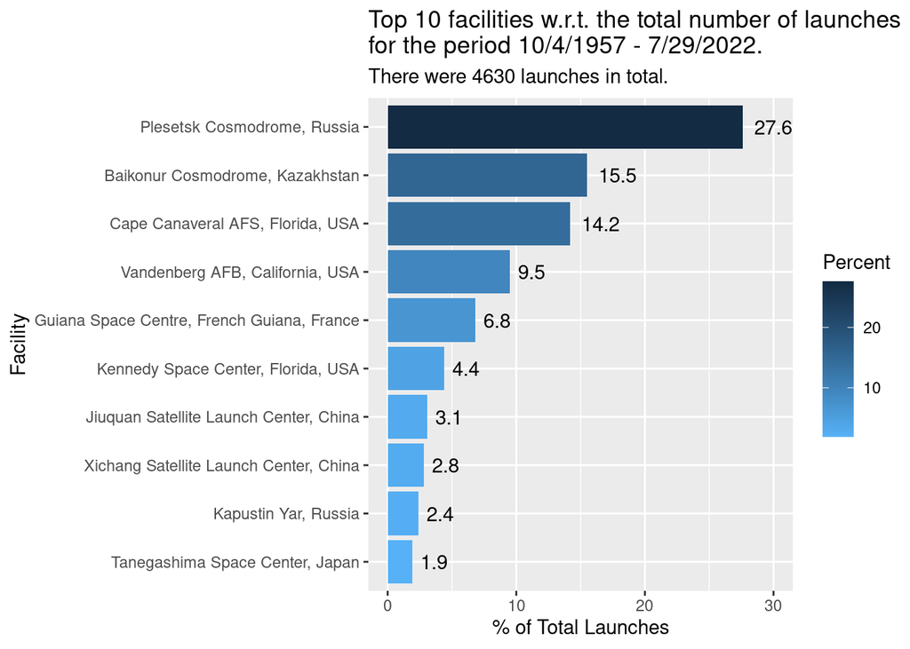

- 90% (4162) of 4630 launches in total were successful.

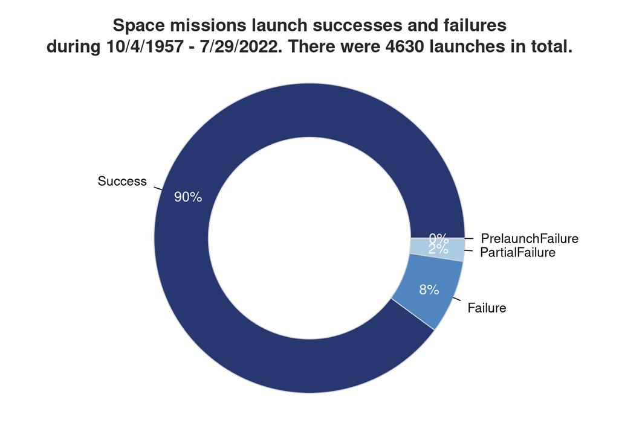

|  | x |
| --- | --- |
| Total | 4630 |
| Success | 4162 |
| Failure | 357 |
| PartialFailure | 107 |
| PrelaunchFailure | 4 |

- Percentage of successful and failed launches is shown below:

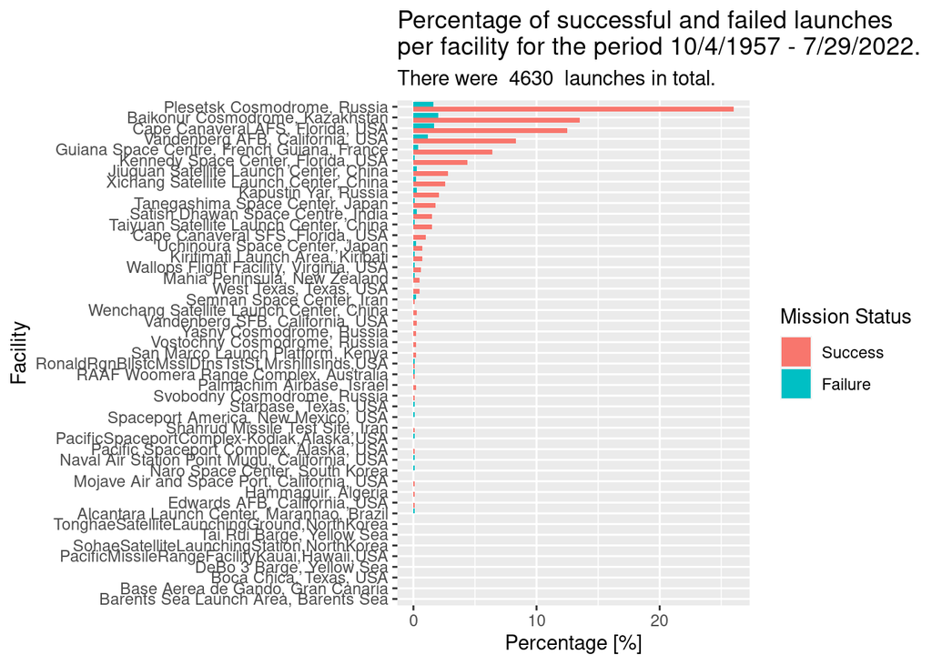

- Top 10 launching facilities with the highest number of space mission launches.

Table 2.4: Top 10 launching facilities for the period 10/4/1957 - 7/29/2022.

| Place | TotalPercent | Total | RelSuccessPerc | RelFailurePerc |
| --- | --- | --- | --- | --- |
| Plesetsk Cosmodrome, Russia | 27.6 | 1278 | 94.1 | 5.9 |
| Baikonur Cosmodrome, Kazakhstan | 15.5 | 719 | 86.9 | 13.1 |
| Cape Canaveral AFS, Florida, USA | 14.2 | 658 | 87.7 | 12.3 |
| Vandenberg AFB, California, USA | 9.5 | 442 | 87.3 | 12.7 |
| Guiana Space Centre, French Guiana, France | 6.8 | 314 | 94.3 | 5.7 |
| Kennedy Space Center, Florida, USA | 4.4 | 205 | 98.5 | 1.5 |
| Jiuquan Satellite Launch Center, China | 3.1 | 144 | 90.3 | 9.7 |
| Xichang Satellite Launch Center, China | 2.8 | 130 | 93.1 | 6.9 |
| Kapustin Yar, Russia | 2.4 | 112 | 85.7 | 14.3 |
| Tanegashima Space Center, Japan | 1.9 | 88 | 95.5 | 4.5 |

- Top 10 facilities with the highest number of launches ordered by successful launches relative to the total number of launches a given facility performed. Kennedy Space Center had the highest relative success value, however, it performed only 4.4% of all global launches.

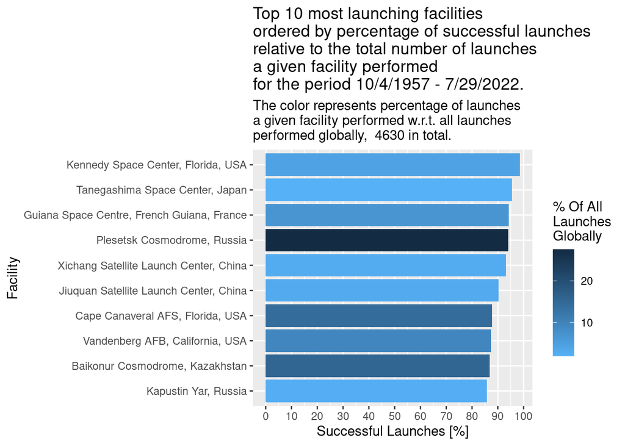

Table 2.5: Facilities with most launches globally ordered by successful launches relative to the number of launches a given facility performed for the period 10/4/1957 - 7/29/2022.

| Place | RelSuccessPerc | TotalPercent | Total |
| --- | --- | --- | --- |
| Kennedy Space Center, Florida, USA | 98.5 | 4.4 | 205 |
| Tanegashima Space Center, Japan | 95.5 | 1.9 | 88 |
| Guiana Space Centre, French Guiana, France | 94.3 | 6.8 | 314 |
| Plesetsk Cosmodrome, Russia | 94.1 | 27.6 | 1278 |
| Xichang Satellite Launch Center, China | 93.1 | 2.8 | 130 |
| Jiuquan Satellite Launch Center, China | 90.3 | 3.1 | 144 |
| Cape Canaveral AFS, Florida, USA | 87.7 | 14.2 | 658 |
| Vandenberg AFB, California, USA | 87.3 | 9.5 | 442 |
| Baikonur Cosmodrome, Kazakhstan | 86.9 | 15.5 | 719 |
| Kapustin Yar, Russia | 85.7 | 2.4 | 112 |

- Descriptive stats regarding launches w.r.t. launches per year for the period 10/4/1957 - 7/29/2022.:

Table 2.6: Stats for the launches for the period 10/4/1957 - 7/29/2022.

|  | Min. | 1st Qu. | Median | Mean | 3rd Qu. | Max. |
| --- | --- | --- | --- | --- | --- | --- |
| LaunchesCount | 3 | 50 | 61.5 | 70.2 | 96 | 157 |

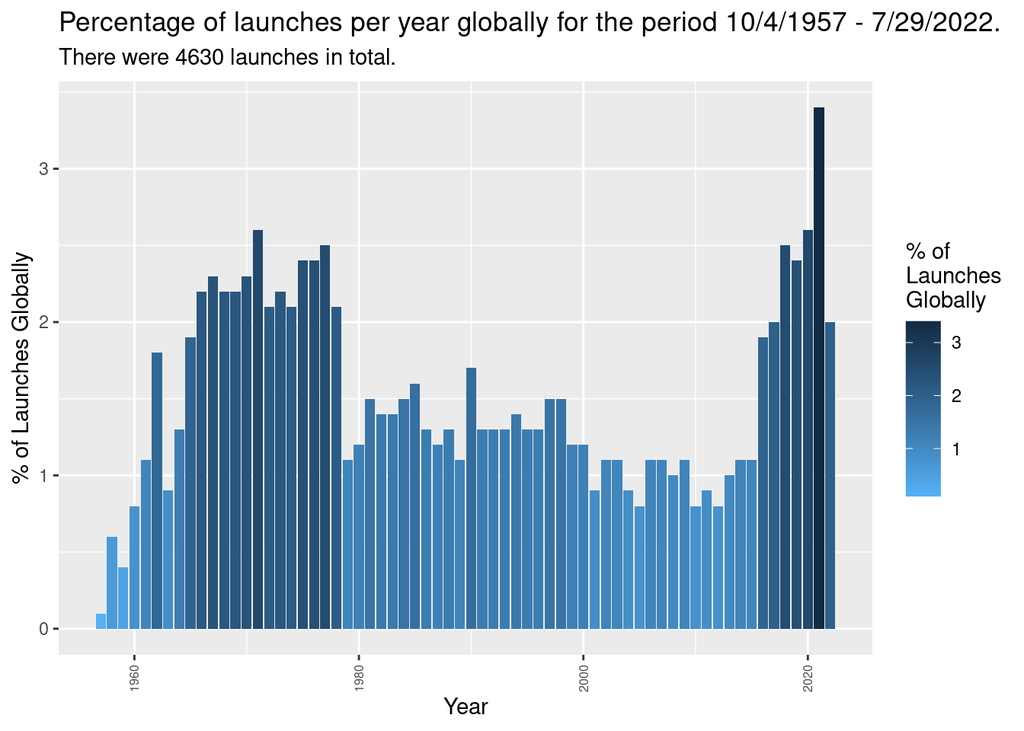

- The highest number of launches was in 2021 (157) and it accounted for 3.4% of global launches.

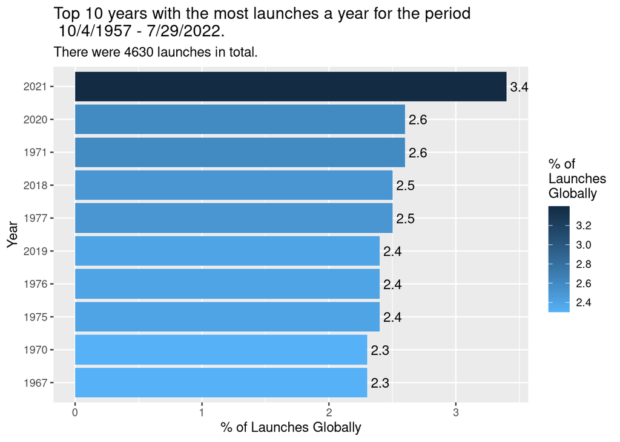

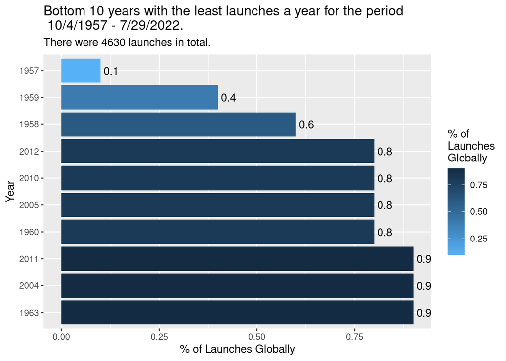

## 2.4 Rockets

- There were total 371 rockets used for launching. Most rockets (97%) performed no more than 50 launches.

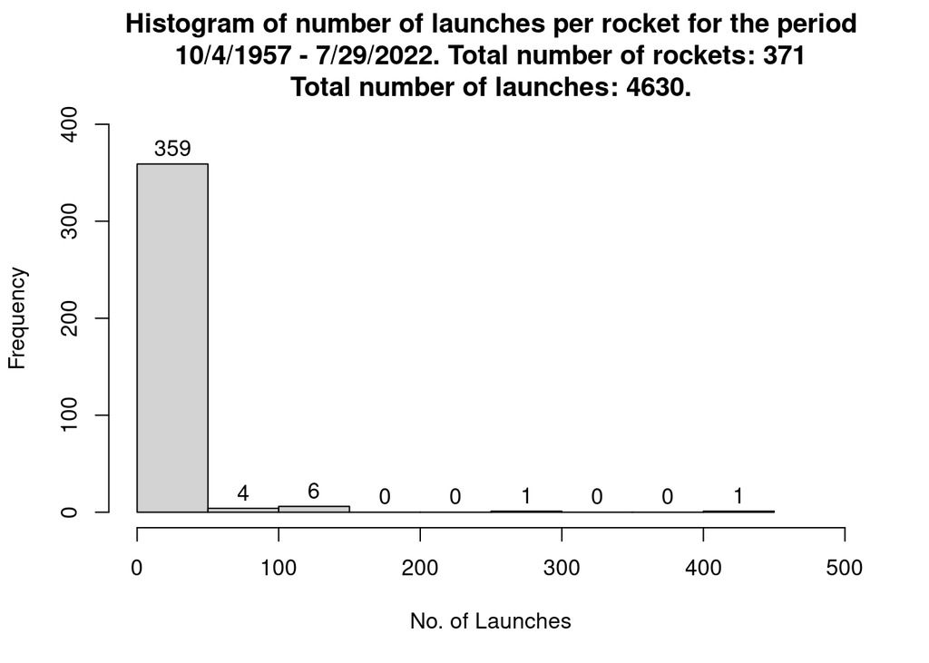

Table 2.7: Stats for rockets for the period 10/4/1957 - 7/29/2022.Total number of rockets used is 371

|  | LaunchCount | FirstLaunch | LastLaunch | OperationInYears |
| --- | --- | --- | --- | --- |
| Min | Min. : 1.00 | Min. :1957-10-04 | Min. :1957-11-03 | Min. : 0.000 |
| Median | Median : 4.00 | Median :1994-03-13 | Median :2003-01-16 | Median : 3.000 |
| Mean | Mean : 12.48 | Mean :1992-03-24 | Mean :1997-12-25 | Mean : 5.758 |
| Max | Max. :446.00 | Max. :2022-07-27 | Max. :2022-07-29 | Max. :43.800 |

- The status of rockets: active vs. retired.

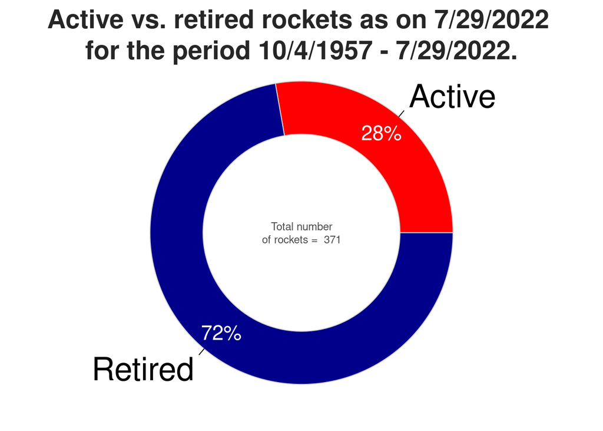

- Rocket Cosmos-3M (11K65M) was the most popular one with 446 launches which accounted for 9.6 of total launches.

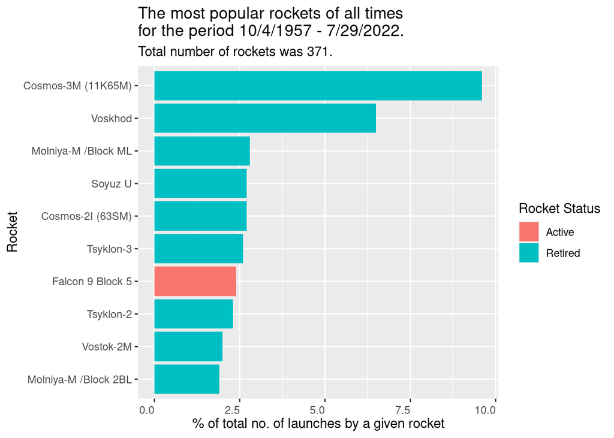

Table 2.8: Most used rockets of all times for the period 10/4/1957 - 7/29/2022.Total number of rockets was 371.

| Rocket | LaunchCount | CountPerc | RocketStatusName | FirstLaunch | LastLaunch | OperationInYears |
| --- | --- | --- | --- | --- | --- | --- |
| Cosmos-3M (11K65M) | 446 | 9.6 | Retired | 1967-05-15 | 2010-04-27 | 43.0 |
| Voskhod | 299 | 6.5 | Retired | 1963-11-16 | 1976-06-29 | 12.6 |
| Molniya-M /Block ML | 128 | 2.8 | Retired | 1974-04-20 | 2005-06-21 | 31.2 |
| Cosmos-2I (63SM) | 126 | 2.7 | Retired | 1965-10-19 | 1977-06-18 | 11.7 |
| Soyuz U | 125 | 2.7 | Retired | 1973-05-18 | 2017-02-22 | 43.8 |
| Tsyklon-3 | 122 | 2.6 | Retired | 1977-06-24 | 2009-01-30 | 31.6 |
| Falcon 9 Block 5 | 111 | 2.4 | Active | 2018-05-11 | 2022-07-24 | 4.2 |
| Tsyklon-2 | 106 | 2.3 | Retired | 1969-08-06 | 2006-06-25 | 36.9 |
| Vostok-2M | 93 | 2.0 | Retired | 1964-08-28 | 1991-08-29 | 27.0 |
| Molniya-M /Block 2BL | 87 | 1.9 | Retired | 1972-09-19 | 2010-09-30 | 38.1 |

- There were total 371 rockets used for launching. Most rockets (64%) operated for no more than 5 years.

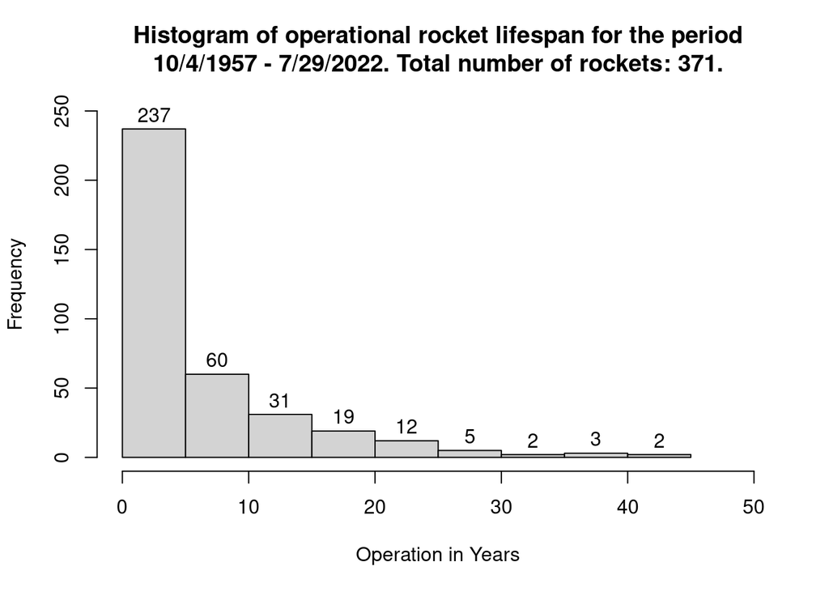

- The longest serving rocket was Soyuz U which served from 1973-05-18 and retired on 2017-02-22, accounting for 43.8 years of operation. The longest serving rocket still active as of the end of period for this dataset was Long March 2C with 39.9 years of operation.

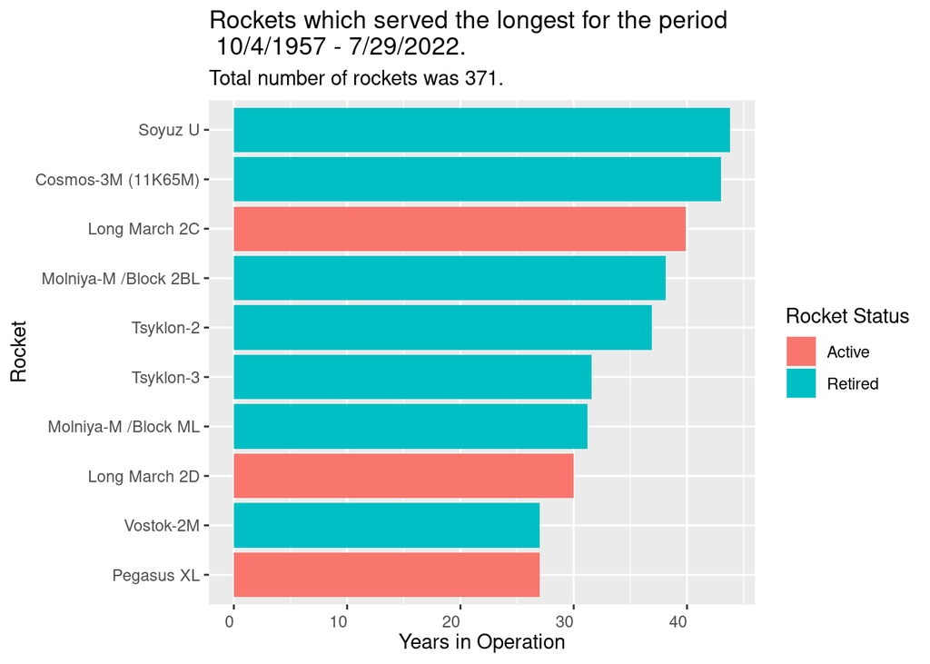

Table 2.9: Rockets that served the longest for the period 10/4/1957 - 7/29/2022.Total number of rockets was 371.

| Rocket | LaunchCount | CountPerc | RocketStatusName | FirstLaunch | LastLaunch | OperationInYears |
| --- | --- | --- | --- | --- | --- | --- |
| Soyuz U | 125 | 2.7 | Retired | 1973-05-18 | 2017-02-22 | 43.8 |
| Cosmos-3M (11K65M) | 446 | 9.6 | Retired | 1967-05-15 | 2010-04-27 | 43.0 |
| Long March 2C | 43 | 0.9 | Active | 1982-09-09 | 2022-07-15 | 39.9 |
| Molniya-M /Block 2BL | 87 | 1.9 | Retired | 1972-09-19 | 2010-09-30 | 38.1 |
| Tsyklon-2 | 106 | 2.3 | Retired | 1969-08-06 | 2006-06-25 | 36.9 |
| Tsyklon-3 | 122 | 2.6 | Retired | 1977-06-24 | 2009-01-30 | 31.6 |
| Molniya-M /Block ML | 128 | 2.8 | Retired | 1974-04-20 | 2005-06-21 | 31.2 |
| Long March 2D | 44 | 1.0 | Active | 1992-08-09 | 2022-07-29 | 30.0 |
| Vostok-2M | 93 | 2.0 | Retired | 1964-08-28 | 1991-08-29 | 27.0 |
| Pegasus XL | 30 | 0.6 | Active | 1994-06-27 | 2021-06-13 | 27.0 |

# 3 Preparing Data

The original data is located at [1]. The data is organized in two .csv files:

- `space_missions.csv` - the actual data
- `space_missions_data_dictionary.csv` - description of fields

| Data Structure | No. of Fields | No. of Records | Date Added |
| --- | --- | --- | --- |
| Single table | 9 | 4,630 + header | 08/03/2022 |

## 3.1 Data Structure

Each observation consists of 9 attributes that describe: Company, Location, Date, Time, Rocket, Mission, RocketStatus, Price, MissionStatus.

- Company - a text field that can includes spaces, variable length
- Location - a text field, variable length, includes: the site, place, state, country. State and country is for USA. Tokens separated by comma.
- Date - m/d/yyyy; m and d can be a single or double digit
- Time - h:m:ss; h and m can be a single or double digit; according description UTC
- Rocket - a text that can have multiple tokens
- Mission - a text that can contain multiple tokens; letter encoding issues
- RocketStatus - textual one word (Retired, Active)
- Price - numeric, often missing
- MissionStatus - (Success, Failure, Partial Failure, Prelaunch Failure)

## 3.2 Data Credibility

The data is provided by a respected website devoted to Data Analytics [1]. I checked and confirmed from other sources a couple randomly selected observations:

- Falcon 9 Block 5 | Nilesat-301 | SpaceX | June 8th, 2022
- Martin Marietta SLC-4E, Vandenberg AFB, California, USA 11/8/1991 7:07:00 Titan IV(403)A SLDCOM & NOSS 3x

## 3.3 Data Bias

To rule out the bias in the data, the research should be performed to verify if all space missions were indeed included within the specified timeline, i.e., 1957-2022. My assumptions is that the data is collected and presented in a fair manner.

## 3.4 License

I have not found any license on how to use the data. I have reached out to the staff and they said that “they [datasets] are free to use as you wish”.

## 3.5 Potential Issues

- Some data is missing. Especially, the price field.
- Mission field has different encoding for letters.
- Location field probably needs to be separated.

## 3.6 Preparation Methodology

I used Microsoft Excel to visually inspect the data and address the issues.

# 4 Data Processing

I could not use pivot tables for the dataset due to a MS Excel memory issue: when trying to create a pivot table from the data csv file with 4,630 observations and 9 attributes, the message showed up:

“Excel cannot complete this task with available resource. Choose less data or close other applications.”

## 4.1 Data Cleaning

Data cleaning has been performed in MS Excel and R. Mostly manually with the help of MS Excel tools such as Find/Replace, Missing Values Filter, and R to find out encoding issues (writing functions that report issues).

It resulted in creation of a file named `space_mission.xlsx` that I used for further data analysis.

### 4.1.1 Field: Location

- Algeria: Corrected the country for launch for - Brigitte, Hammaguir, Algeria, France. Removed France because the location is in Algeria, not in France (4 occurrences).
- Kiribati: Kiritimati Launch Area has Pacific Ocean, although it belongs to the Republic of Kiribati (36 occurrences)
- Barents Sea: it was launched in the Barents Sea Launch Area by Russian submarines (3 occurrences).
- Yellow Sea

### 4.1.2 Field: Date

- Added missing Date for “Rocket Lab Rocket Lab LC-1A, Mahia Peninsula, New Zealand 0:02:00 Electron/Curie  
  A Data With Destiny”

### 4.1.3 Field: Time

- There are 127 missing values. I have tried to find first ten of them to no avail.

### 4.1.4 Field: MissionStatus

I added a numerical field that I used in csv later on:

| Original MissionStatus | Numerical MissionStatus |
| --- | --- |
| Success | 1 |
| Failure | 2 |
| Partial Failure | 3 |
| Prelaunch Failure | 4 |

### 4.1.5 Checks

Total number of observations: 4630

| Field | Missing | Range/Values |
| --- | --- | --- |
| Company | 0 | len: 2-16 |
| Location | - | - |
| Site | 23 | len: 0-23 |
| Facility | 3 | len: 0-49 |
| State | 2839 | len: 0-16 |
| Area | 0 | len: 3-13 |
| Date | 0 | 10/4/1957 - 7/29/2022 |
| Time | 127 | 0:00-23:59 |
| Rocket | 0 | len: 3-24 |
| Mission | 0 | len: 3-51 |
| RocketStatus | 0 | Retired, Active |
| Price (millions of $) | 3365 | 2.5 - 5,000 |
| MissionStatus | 0 | Success, Failure, Partial Failure, Prelaunch Failure |

### 4.1.6 Result

I cleaned manually names from all characters that might be problematic for the databases or further processing.

I created the `space-mission.xlsx` file and exported `missions.csv` and `places.csv` that can be used in further processing.

- `places.csv` - contains part of the original location, i.e., facility, state, area
- `missions.csv` - contains RocketStatus and MissionStatus changed to numbers, it also has an additional field called ID of the mission.
- `missions-all-fields.csv` - contains numeric values of RocketStatus and MissionStatus, the location has four elements

# References

[1]

M. Analytics, “Space Missions.” Maven Analytics, Nov. 2022. Available: https://app.mavenanalytics.io/datasets